# Day 0: R入門

# はじめに

本稿はRに関する簡単な紹介および画面説明を目的とします．

# Rとは

Rはオープンソースの統計解析ソフトウェアです．

マルチプラットフォーム対応でWindows，MacOS，各種UNIX OSで動作します．

https://www.r-project.org/

対話型インタフェースが採用されており，R言語とよばれるスクリプト言語を使って操作します．

拡張性が高く，拡張パッケージをインストールすることで，Rに新しい機能を追加することもできます．

拡張パッケージを公開するThe Comprehensive R Archive Network（CRAN）には9,000を超えるパッケージが登録されています(2016年10月1日時点)．

https://cran.rstudio.com/web/packages/

こうした拡張性の高さもRの魅力の一つです．

ただし，R にも限界があります．

Rは基本的にオンメモリで処理を行うため，大規模計算には向いていません．

それを補うための拡張パッケージ（たとえば [ff](https://cran.r-project.org/web/packages/ff/index.html)，[bigmemory](https://cran.r-project.org/web/packages/bigmemory/index.html)，[h2o](https://cran.r-project.org/web/packages/h2o/index.html)など）も開発されていますが，基本的には小・中規模計算用と考えたほうが無難です．

もちろん実践で使用できるレベルです．少しソースが古いですが，大手企業でも利用されているようです．

http://blog.revolutionanalytics.com/2014/05/companies-using-r-in-2014.html

無料だからといって機能不足とは感じることは殆ど無いでしょう．

# Rの起動と操作画面の説明

R の起動方法を説明します．最近の R には 32bit バージョンと 64bit バージョンがあります．

特別な理由がない限り 64bit バージョンを利用するようにしましょう．

見分け方は「i386」とある場合は 32bit バージョン，「x64」とある場合は 64bit バージョンです．

MacOS 版には区別はありません．

## Rの操作画面(Windows)

R を起動すると以下のような画面が表示されます．R の標準画面構成は，Multiple Document Interface(MDI)，すなわち，一つの親ウィンドウに複数の子ウィンドウを開く画面構成，となります．

[figure not shown]

Windows版R MDI(Multiple Document Interface)画面

設定変更することで Single Document Interface(SDI)，複数のウィンドウを別々に開く画面構成，に変更することもできます．

変更する場合は「Rgui 設定エディター」，メニュー[編集] > [GUIプリファレンス]で MDI となっている箇所を SDI とすると変更できます．変更には設定ファイルの保存が必要になります．

[figure not shown]

Windows版R SDI(Single Document Interface)画面

### ツールバー

ツールバーの各アイコンの名前は以下の通りです．「スクリプトの読み込み」「実行中の処理の中断」などが素早くできます．

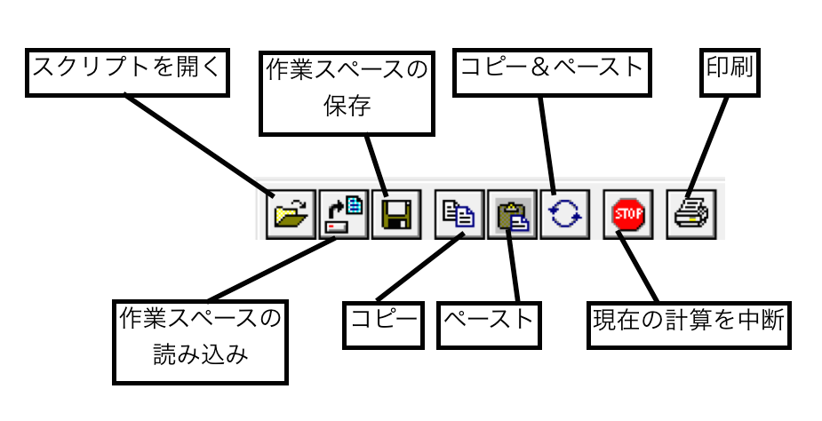

Windows版Rのツールバー

## Rの操作画面（MacOS）

MacOS 版の画面構成は以下の通りです．Windows 版と比較して若干の画面上の違いはありますが，基本的な使い方は変わりません．

[figure not shown]

OS X版Rの画面

### ツールバー

MacOS 版のメニューは以下の通りです．

[figure not shown]

OS X版Rのメニュー

MacOS 版のツールバーの各アイコンの名前は以下の通りです．

Windows 版と比較して難解な機能が含まれていますが「スクリプトの読み込み」「実行中の処理の中断」など，基本的なコマンドは容易されています．

[figure not shown]

OS X版Rのツールバー

# 対話型インタフェース

対話型インタフェースの使い方を説明します．

「コンソール」に「1+1」と入力してください．

[figure not shown]

上記画面のように「1+1」と入力したらエンターキーを押してください．

[figure not shown]

「1+1」がRによって計算され，結果である「2」が表示されています．

今度はコンソールに「1+2+3-5」と入力し，エンターキーを押してください．

[figure not shown]

「1+2+3-5」の計算結果「1」が表示されています．

このようにRではコンソールを介して，対話的な操作を行うことで，計算を実行したり，グラフを描いたりします．

Rでは以下の算術演算子を計算で使うことができます．

| 演算 | 演算子 | 例 |
| --- | --- | --- |
| 加算 | + | x + y |
| 減算 | - | x - y |
| 乗算 | * | x * y |
| 除算 | / | x / y |
| べき算 | ^ | x ^ y |
| 剰余算 | %% | x %% y |
| 整数除算 | %/% | x %/% y |

次にグラフを描いてみましょう．

コンソールに以下のコードを入力して下さい．

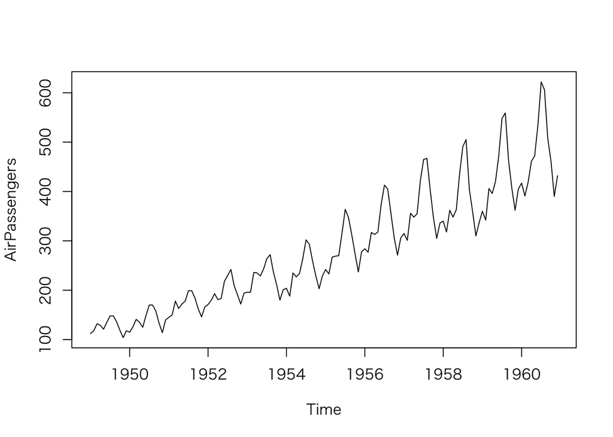

```r
#データを読み込む
data("AirPassengers")
#乗客数をプロット
plot(AirPassengers)
```

```r
#データの説明
?AirPassengers
```

別のグラフを描いてみましょう．

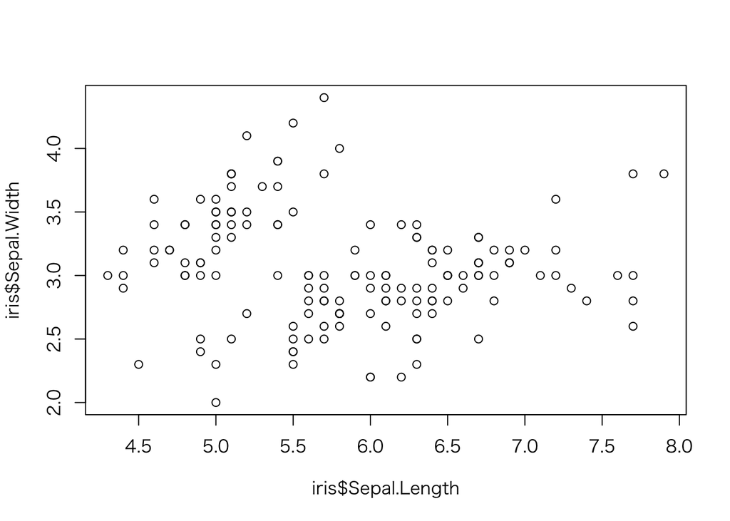

```r
#データを読み込む
data("iris")
#萼片長と幅をプロット
plot(iris$Sepal.Length,iris$Sepal.Width)
```

```r
#データの説明（ヘルプの表示）
?iris
```

Rで困ったことがあったら「?command」でヘルプを参照します．

最後にデータを用意して作図します．

```r
#1 - 100 までの連続値を作成する．
x = 1:100
#xの中身を表示する．
x
```

```
##   [1]   1   2   3   4   5   6   7   8   9  10  11  12  13  14  15  16  17
##  [18]  18  19  20  21  22  23  24  25  26  27  28  29  30  31  32  33  34
##  [35]  35  36  37  38  39  40  41  42  43  44  45  46  47  48  49  50  51
##  [52]  52  53  54  55  56  57  58  59  60  61  62  63  64  65  66  67  68
##  [69]  69  70  71  72  73  74  75  76  77  78  79  80  81  82  83  84  85
##  [86]  86  87  88  89  90  91  92  93  94  95  96  97  98  99 100
```

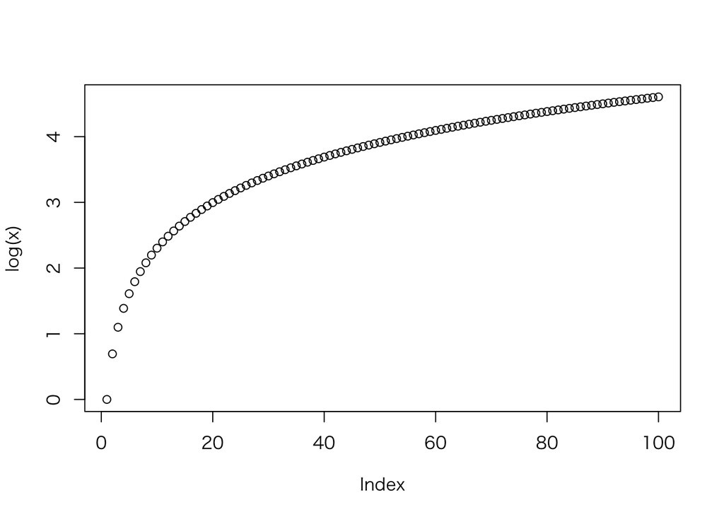

```r
#対数をとってプロットする
plot(log(x))
```

# おわりに

以上で簡単な説明は終わりです．基本は「習うより慣れろ」でいけるはずです．

R関係の文書は基本的にウェブから入手可能です．検索したり，下記サイトを漁ってみてください．

- R入門(R-introの日本語訳)
  - http://cran.r-project.org/doc/contrib/manuals-jp/R-intro-170.jp.pdf
- R-Tips：Rの使い方
  - http://cse.naro.affrc.go.jp/takezawa/r-tips/r2.html
- RjpWiki：RのWiki
  - http://www.okada.jp.org/RWiki/
- R-bloggers: Rの最新情報，チュートリアル（英語）
  - http://www.r-bloggers.com/
- R による統計処理 サポートページ
  - http://aoki2.si.gunma-u.ac.jp/R/index.html
- try R
  - http://tryr.codeschool.com/

書籍で読みたい場合は以下がわかりやすい．RStudioまわりの使い方も書いてある．

- みんなのR -データ分析と統計解析の新しい教科書-,マイナビ,ISBN:4839955212

戻る

Masaharu Hayashi を著作者とするこの 作品 は [クリエイティブ・コモンズの 表示 4.0 国際 ライセンス](http://creativecommons.org/licenses/by/4.0/)で提供されています。